# Income Qualification Project

## Description

Identify the level of income qualification needed for the families in Latin America.

### Problem Statement Scenario:

Many social programs have a hard time ensuring that the right people are given enough aid. It’s tricky when a program focuses on the poorest segment of the population. This segment of the population can’t provide the necessary income and expense records to prove that they qualify.

In Latin America, a popular method called Proxy Means Test (PMT) uses an algorithm to verify income qualification. With PMT, agencies use a model that considers a family’s observable household attributes like the material of their walls and ceiling or the assets found in their homes to classify them and predict their level of need.

While this is an improvement, accuracy remains a problem as the region’s population grows and poverty declines.

The Inter-American Development Bank (IDB)believes that new methods beyond traditional econometrics, based on a dataset of Costa Rican household characteristics, might help improve PMT’s performance.

```python
#Data Accquisition and Manipulation libraries
import pandas as pd
import numpy as np

#Data Visualization
import matplotlib as plt
import seaborn as sns
%matplotlib inline

#Read Data
pd.set_option('display.max_rows', 500)
train = pd.read_csv('train.csv')
test = pd.read_csv('test.csv')

#View Data
train.head()
```

|  | Id | v2a1 | hacdor | rooms | hacapo | v14a | refrig | v18q | v18q1 | r4h1 | ... | SQBescolari | SQBage | SQBhogar_total | SQBedjefe | SQBhogar_nin | SQBovercrowding | SQBdependency | SQBmeaned | agesq | Target |
| --- | --- | --- | --- | --- | --- | --- | --- | --- | --- | --- | --- | --- | --- | --- | --- | --- | --- | --- | --- | --- | --- |
| 0 | ID_279628684 | 190000.0 | 0 | 3 | 0 | 1 | 1 | 0 | NaN | 0 | ... | 100 | 1849 | 1 | 100 | 0 | 1.000000 | 0.0 | 100.0 | 1849 | 4 |
| 1 | ID_f29eb3ddd | 135000.0 | 0 | 4 | 0 | 1 | 1 | 1 | 1.0 | 0 | ... | 144 | 4489 | 1 | 144 | 0 | 1.000000 | 64.0 | 144.0 | 4489 | 4 |
| 2 | ID_68de51c94 | NaN | 0 | 8 | 0 | 1 | 1 | 0 | NaN | 0 | ... | 121 | 8464 | 1 | 0 | 0 | 0.250000 | 64.0 | 121.0 | 8464 | 4 |
| 3 | ID_d671db89c | 180000.0 | 0 | 5 | 0 | 1 | 1 | 1 | 1.0 | 0 | ... | 81 | 289 | 16 | 121 | 4 | 1.777778 | 1.0 | 121.0 | 289 | 4 |
| 4 | ID_d56d6f5f5 | 180000.0 | 0 | 5 | 0 | 1 | 1 | 1 | 1.0 | 0 | ... | 121 | 1369 | 16 | 121 | 4 | 1.777778 | 1.0 | 121.0 | 1369 | 4 |

5 rows × 143 columns

```python
#Columns in Data
column_names_train = np.array(train.columns)
# print(column_names_train)

#Data Description
print(train.count())
print(train.Target.unique())
```

```
Id                 9557
v2a1               2697
hacdor             9557
rooms              9557
hacapo             9557
v14a               9557
refrig             9557
v18q               9557
v18q1              2215
r4h1               9557
r4h2               9557
r4h3               9557
r4m1               9557
r4m2               9557
r4m3               9557
r4t1               9557
r4t2               9557
r4t3               9557
tamhog             9557
tamviv             9557
escolari           9557
rez_esc            1629
hhsize             9557
paredblolad        9557
paredzocalo        9557
paredpreb          9557
pareddes           9557
paredmad           9557
paredzinc          9557
paredfibras        9557
paredother         9557
pisomoscer         9557
pisocemento        9557
pisoother          9557
pisonatur          9557
pisonotiene        9557
pisomadera         9557
techozinc          9557
techoentrepiso     9557
techocane          9557
```

[output cut: 90 more lines]

```
area1              9557
area2              9557
age                9557
SQBescolari        9557
SQBage             9557
SQBhogar_total     9557
SQBedjefe          9557
SQBhogar_nin       9557
SQBovercrowding    9557
SQBdependency      9557
SQBmeaned          9552
agesq              9557
Target             9557
dtype: int64
[4 2 3 1]
```

#### Objective 1: Identify the output variable

Answer - As we examine the dataset, we find **'Target'** to be the output variable

#### Objective 2: Understand the type of data

Answer - As follows

```python
train.dtypes
```

```
Id                  object
v2a1               float64
hacdor               int64
rooms                int64
hacapo               int64
v14a                 int64
refrig               int64
v18q                 int64
v18q1              float64
r4h1                 int64
r4h2                 int64
r4h3                 int64
r4m1                 int64
r4m2                 int64
r4m3                 int64
r4t1                 int64
r4t2                 int64
r4t3                 int64
tamhog               int64
tamviv               int64
escolari             int64
rez_esc            float64
hhsize               int64
paredblolad          int64
paredzocalo          int64
paredpreb            int64
pareddes             int64
paredmad             int64
paredzinc            int64
paredfibras          int64
paredother           int64
pisomoscer           int64
pisocemento          int64
pisoother            int64
pisonatur            int64
pisonotiene          int64
pisomadera           int64
techozinc            int64
techoentrepiso       int64
techocane            int64
```

[output cut: 89 more lines]

```
lugar6               int64
area1                int64
area2                int64
age                  int64
SQBescolari          int64
SQBage               int64
SQBhogar_total       int64
SQBedjefe            int64
SQBhogar_nin         int64
SQBovercrowding    float64
SQBdependency      float64
SQBmeaned          float64
agesq                int64
Target               int64
dtype: object
```

#### Objective 3: Check if there are any biases in your dataset

Answer - As we can see in the graph, the data is biased towards Target value 4 as it has the maximum output variable i.e. 5996. The code for graph and values are mentioned below.

```
Target
1     755
2    1597
3    1209
4    5996
dtype: int64
```

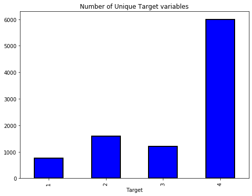

```python
train.groupby("Target").size().plot.bar(color = 'blue', figsize = (8,6), edgecolor = 'k', linewidth = 2, title = "Number of Unique Target variables");

print(train.groupby("Target").size())
```

#### Objective 4: Check whether all members of the house have the same poverty level

Answer - The dataset represents all the details of a particular individual. As per dataset description, "idhogar" represents the identifier if that individual belongs to a unique household. The "Target" displays the poverty level of the household in the form of 4 levels. The objective is to check whether all the members of a household have the same poverty level. In order to do the same, we group the dataset by the identifier and sum up all the groups, showing different target values. The code for the same is mentioned below.

##### Thus, 85 Households where all the members do not have the same poverty level.

```python
unique_household = train.groupby("idhogar")["Target"].nunique() != 1
unique_household.sum()
```

```
85
```

#### Objective 5: Check if there is a house without a family head

Answer - To check if there is a house without a family head, we group them on the basis of "idhogar" and check how many of the household have "parentesco1 == 0". The code for the same is mentioned below.

##### Thus, 15 Households are without a family head

```python
househead = train.groupby("idhogar")["parentesco1"].sum()
househead_count = househead.count() - househead.sum()
househead_count
```

```
15
```

#### Objective 6: Set poverty level of the members and the head of the house within a family

Answer - Target variable treatment, according to the objective is done in the following manner.

```python
all_equal = train.groupby('idhogar')['Target'].apply(lambda x: x.nunique() == 1)
household = all_equal[all_equal != True]
for i in household.index:
    poverty_value = int(train[(train["idhogar"] == i) & (train["parentesco1"] == 1.0)]["Target"])
    train.loc[train["idhogar"] == i, "Target"] = poverty_value
```

#### Objective 7: Count how many null values are existing in columns

Answer - All the null values arranged in descending order are mentioned below. We can see the majority of the null values are in the columns "rez_esc", "v18q1" and "v2a1"

```python
missing_values = train.isnull().sum()
missing_values.sort_values(ascending = False)
```

```
rez_esc            7928
v18q1              7342
v2a1               6860
meaneduc              5
SQBmeaned             5
techozinc             0
techoentrepiso        0
techocane             0
techootro             0
cielorazo             0
abastaguadentro       0
sanitario3            0
abastaguafuera        0
abastaguano           0
public                0
planpri               0
noelec                0
coopele               0
sanitario1            0
sanitario2            0
Target                0
sanitario5            0
elimbasu4             0
etecho1               0
epared3               0
epared2               0
epared1               0
elimbasu6             0
elimbasu5             0
elimbasu3             0
pisomadera            0
elimbasu2             0
elimbasu1             0
energcocinar4         0
energcocinar3         0
energcocinar2         0
energcocinar1         0
sanitario6            0
pisonatur             0
pisonotiene           0
```

[output cut: 89 more lines]

```
parentesco8           0
parentesco9           0
parentesco10          0
parentesco11          0
parentesco12          0
idhogar               0
hogar_nin             0
hogar_adul            0
hogar_mayor           0
hogar_total           0
dependency            0
edjefe                0
edjefa                0
Id                    0
dtype: int64
```

#### Objective 8: Remove null value rows of the target variable

Answer - Firstly, we will check if there are any null values in the dataset or not. As we can observe below, there is no null values. Thus, the Target variable will not be imputed. This concept may be used, when we combine the train and test dataset for overall Exploratory Data Analysis, to segregate the two dataset, post EDA and feature engineering.

```python
train["Target"].isnull().sum()
```

```
0
```

#### Objective 9: Predict the accuracy using random forest classifier

Answer - In order to run the Random Forest Classifier on the dataset, we need to perform certain Feature engineering and EDA processes, to structure and clean the data. This includes removing of unwanted columns, converting data types into the correct form, imputing NaN values as well as removing certain columns with leftover NaN values and creating testing and training datasets, using the train_test_split function. The accuracy is calculated as below.

```python
x_train = train.drop(["Id","idhogar"], axis=1)


#Transforming columns with multiple dtype entries to single dtype entry
x_train.loc[x_train["dependency"] == "no", "dependency"] = 0
x_train.loc[x_train["edjefe"] == "no", "edjefe"] = 0
x_train.loc[x_train["edjefa"] == "no", "edjefa"] = 0
x_train.loc[x_train["dependency"] == "yes", "dependency"] = 1
x_train.loc[x_train["edjefe"] == "yes", "edjefe"] = 1
x_train.loc[x_train["edjefa"] == "yes", "edjefa"] = 1

#Changing to correct datatypes
x_train[["dependency","edjefe","edjefa"]] = x_train[["dependency","edjefe","edjefa"]].apply(pd.to_numeric)

#Filling NaN values according to the definition of the columns
x_train["v18q1"] = x_train["v18q1"].fillna(0)
x_train["v2a1"] = x_train["v2a1"].fillna(0)
x_train.loc[((x_train['age'] > 19) | (x_train['age'] < 7)) & (x_train['rez_esc'].isnull()), 'rez_esc'] = 0

#Removing left NaN value rows
x_train.dropna(inplace = True)

#Creating Target Variable dataset
y_train = x_train["Target"]
x_train = x_train.drop("Target", axis=1)

from sklearn.model_selection import train_test_split
Feature_Train, Feature_Test, Label_Train, Label_Test = train_test_split(x_train, y_train, test_size = 0.25, random_state = 42)

#Using Random Forest Classifier
from sklearn.ensemble import RandomForestClassifier
rfc_model = RandomForestClassifier(n_estimators=150, random_state= 43)
rfc_model.fit(Feature_Train,Label_Train)
Predict_Test = rfc_model.predict(Feature_Test)

from sklearn.metrics import accuracy_score
accuracy = accuracy_score(Predict_Test,Label_Test)
print("The Prediction accuracy of the Random Forest Classifier on testing data is: " , accuracy)
```

```
The Prediction accuracy of the Random Forest Classifier on testing data is:  0.9365768896611643
```

#### Objective 10: Check the accuracy using random forest with cross validation

Answer - As we can see that the prediction accuracy of the random forest classifier on testing data is 93.65%, which is quite high, we may observe similar results with cross validation estimator. Upon running the code for cross validation estimator on random forest classifier model with increasing folds by increasing the cv value, we noticed that cv > 20 may produce an accuracy of 92% and above. The code for the same is mentioned below.

```python
from sklearn.model_selection import cross_val_score
cross_val_score(rfc_model, Feature_Train, Label_Train, cv= 20, scoring='accuracy').mean()
```

```
0.9200590600653431
```